# Part1

##### Summary of the first plane

The first dimension aims to characterize individuals with a high positive coordinate on the axis (right) and with a high negative coordinate (left).

Firstly, there are a group of individuals on the right with both mother and father having higher education, mother and father working as a teacher, no class failures and the best performance group based by the final grade. Additionally, they are sharing being active, young, having a mother work in health sector and having family support. On the contrary, there are low frequency scores for mother and father having only elementary level or no education, mother or father work as other or mother being at home, having class failures. Additionally no activities, belonging to the lowest performance group category, average health group and have no family support.

Secondly, there are a group of individuals on the left with class failures one, lowest performancegroup, no willingness to higher education, high alcohol consumption and the oldest age category. Additionally, to some extent common are mother having low educational level, going out with friends, mother work as other or have average level education as well as being a male. Low frecuencies are no class failures, mother and father being high school educated, young age group, mother working as a teacher, best performance group, being a female and having a teacher father.

Thirdly, there is a group on the left with mother and father having little education, health being average, gender female, no alcohol, mother working at home and father as other, having a positive attitude towards high edution, performing at an almost average level and sometimes going out with friends. Low frequencies are there for mother´s or father´s higher education, mother working as a teacher, being a male, using alcohol, going out a lot, father being a teacher, health being very good, having no ideas about further education and haing some class failures.

The dimension 2 opposes individuals characterized by a strongly positive coordinate on the axis (to the top of the graph) to individuals characterized by a strongly negative coordinate on the axis (to the bottom of the graph). The group 1 (characterized by a positive coordinate on the axis) is sharing : .high frequency for factors like Class_failures=Class_failures_1, Performancegroup=(-Inf,10], Education_pos=Education_pos_no, High_alcohol=High_alcohol_1, Agegroup=(17,Inf], Education_F=Education_F_(-1,2], Going_out=Going_out_(3,5], Job_M=Job_M_other, Education_M=Education_M_(2,3] and Gender=M (factors are sorted from the most common). .low frequency for factors like Class_failures=Class_failures_0, Education_M=Education_M_(3,4], Education_F=Education_F_(3,4], Education_pos=Education_pos_yes, High_alcohol=High_alcohol_0, Agegroup=(0,16], Job_M=Job_M_teacher, Performancegroup=(14, Inf], Gender=F and Job_F=Job_F_teacher (factors are sorted from the rarest).

The group 2 (characterized by a positive coordinate on the axis) is sharing : .high frequency for factors like Education_M=Education_M_(3,4], Education_F=Education_F_(3,4], Job_M=Job_M_teacher, Job_F=Job_F_teacher, Class_failures=Class_failures_0, Performancegroup=(14, Inf], Activities=Activities_yes, Agegroup=(0,16], Job_M=Job_M_health and Familial_support=Familial_support_yes (factors are sorted from the most common). .low frequency for factors like Education_M=Education_M_(-1,2], Education_F=Education_F_(-1,2], Job_M=Job_M_other, Job_F=Job_F_other, Job_M=Job_M_at_home, Class_failures=Class_failures_1, Activities=Activities_no, Performancegroup=(-Inf,10], Healthgroup=Healthgroup_(2,3] and Familial_support=Familial_support_no (factors are sorted from the rarest).

The group 3 (characterized by a negative coordinate on the axis) is sharing : .high frequency for factors like Education_M=Education_M_(-1,2], Education_F=Education_F_(-1,2], Healthgroup=Healthgroup_(2,3], Gender=F, High_alcohol=High_alcohol_0, Job_M=Job_M_at_home, Job_F=Job_F_other, Performancegroup=(10,12], Going_out=Going_out_(0,2] and Education_pos=Education_pos_yes (factors are sorted from the most common). .low frequency for factors like Education_M=Education_M_(3,4], Education_F=Education_F_(3,4], Job_M=Job_M_teacher, Gender=M, High_alcohol=High_alcohol_1, Going_out=Going_out_(3,5], Job_F=Job_F_teacher, Healthgroup=Healthgroup_(3,5], Education_pos=Education_pos_no and Class_failures=Class_failures_1 (factors are sorted from the rarest).

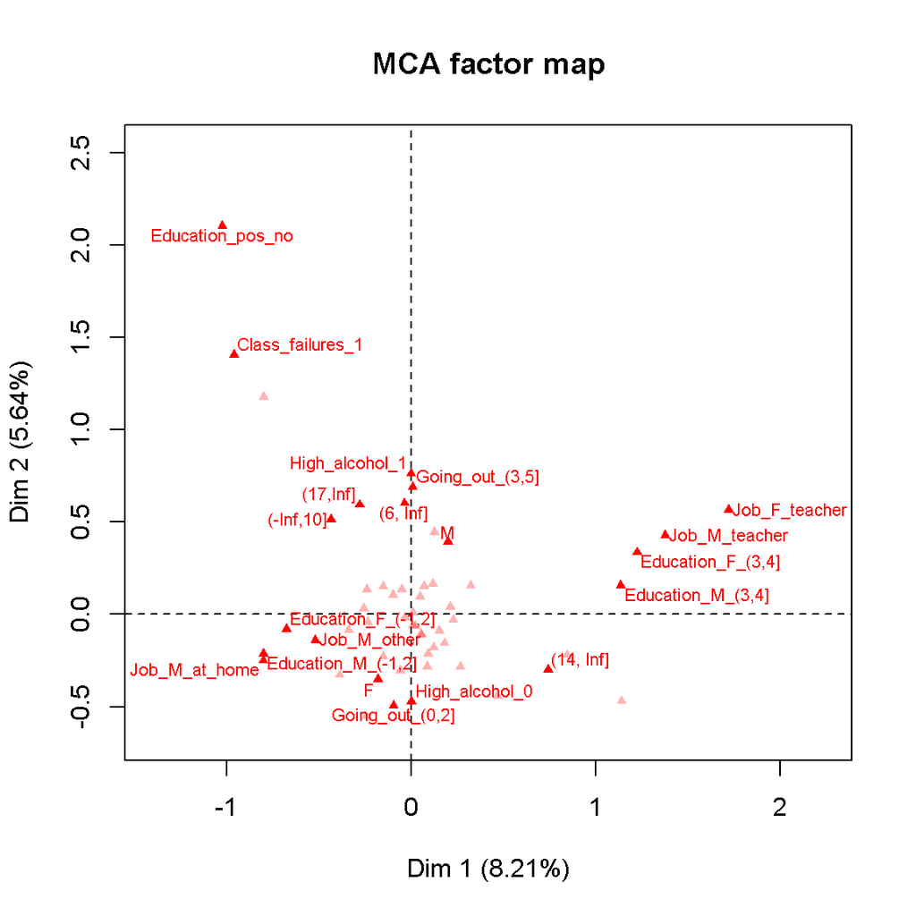

```r
plot(res_mca, invisible=c("ind"), autolab="y",cex=0.7,selectMod="contrib 20")
```

Select allows us to select individuals

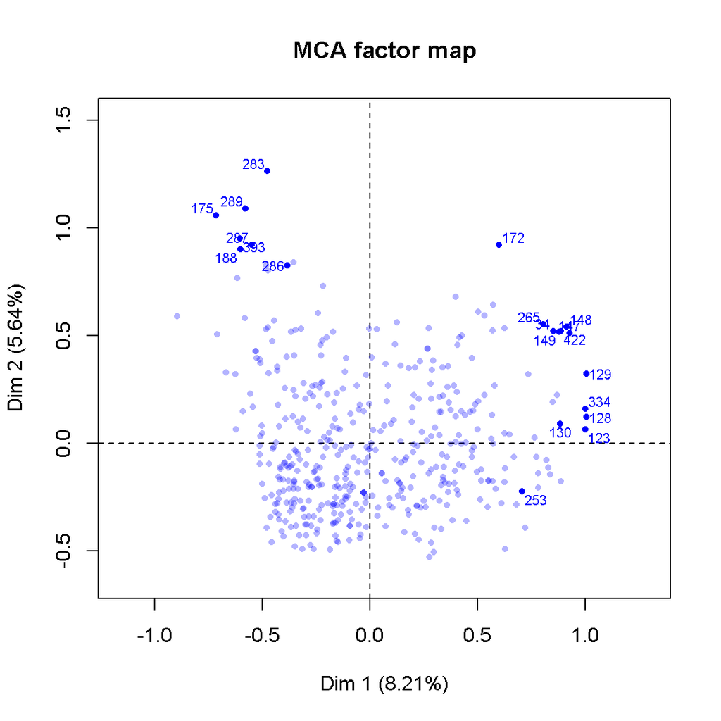

```r
plot(res_mca, invisible=c("var","quanti.sup"), autolab="y",cex=0.7,select="cos2 20")
```

Simultanous representation with a selection for the individuals with select and a selection for the categories with Selectmod

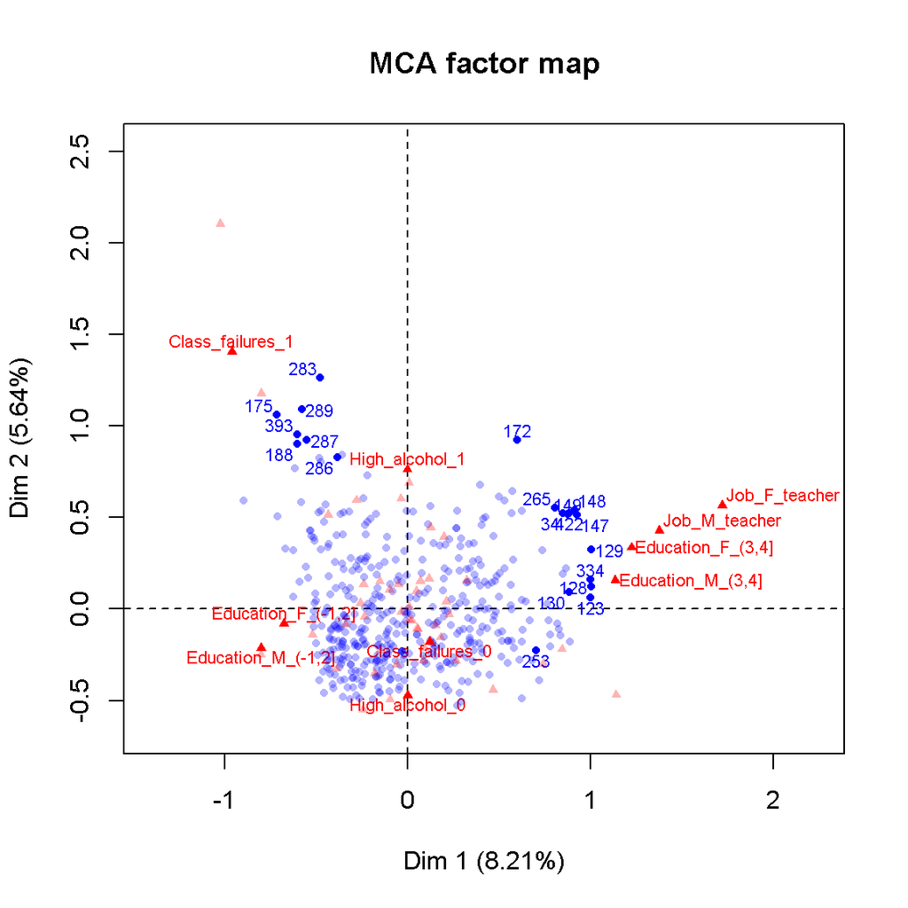

```r
plot(res_mca, autolab="y",cex=0.7,select="cos2 20",selectMod="cos2 10")
```

Graphs of the variables

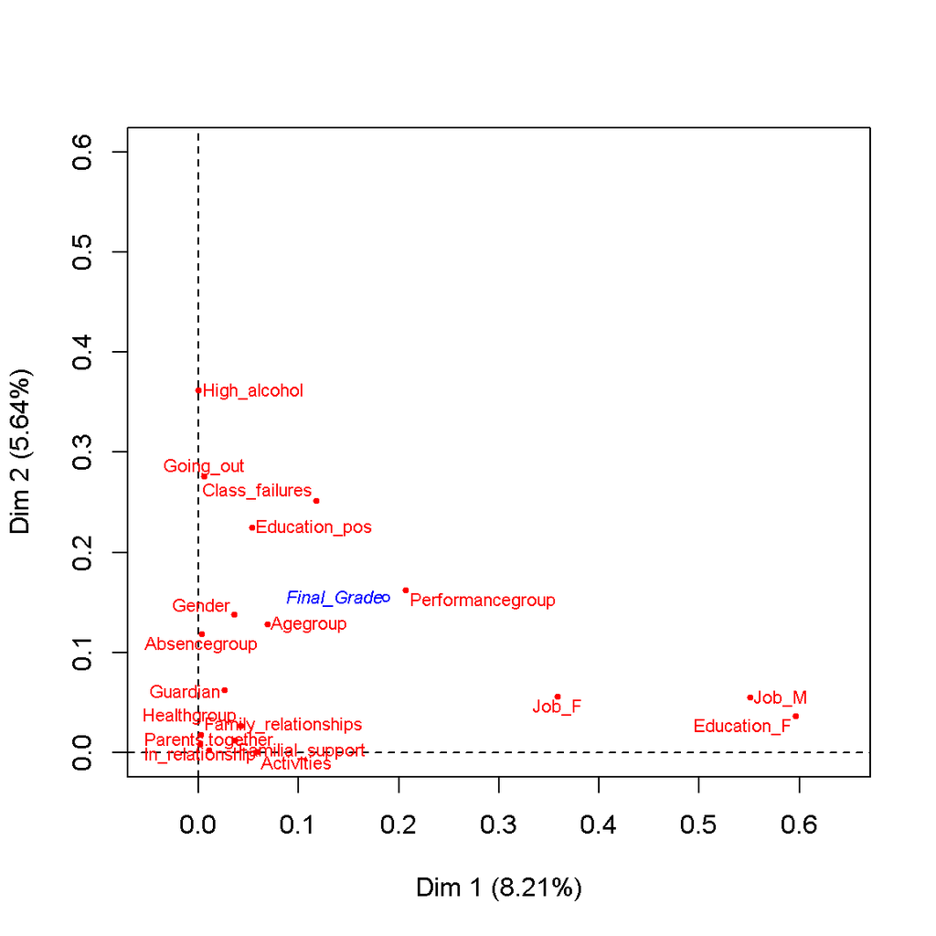

```r
plot(res_mca, choix="var",xlim=c(0,0.6), ylim=c(0,0.6),cex=0.7)
```

To plot dimensions 3 and four we simply define the axis:

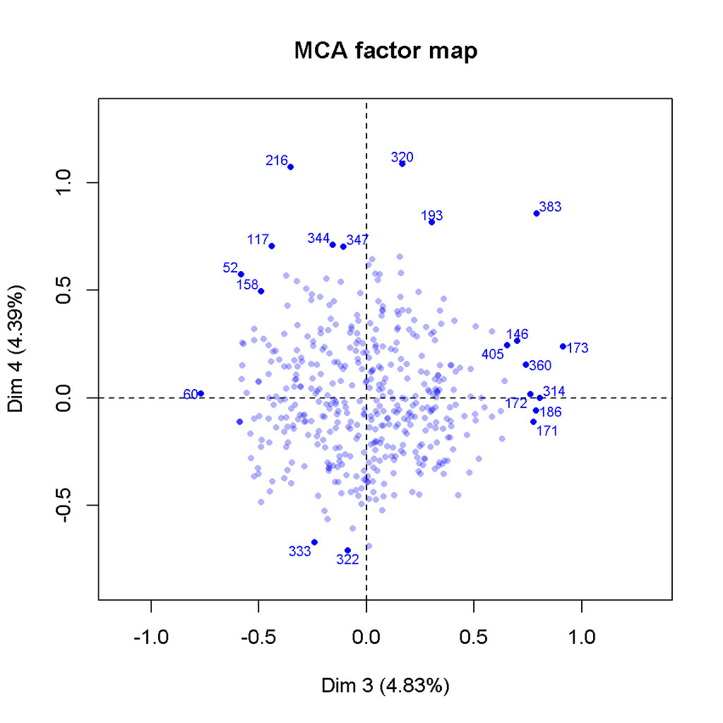

```r
plot(res_mca, invisible=c("var"), select="contrib 20", axes=3:4,cex=0.7)
```

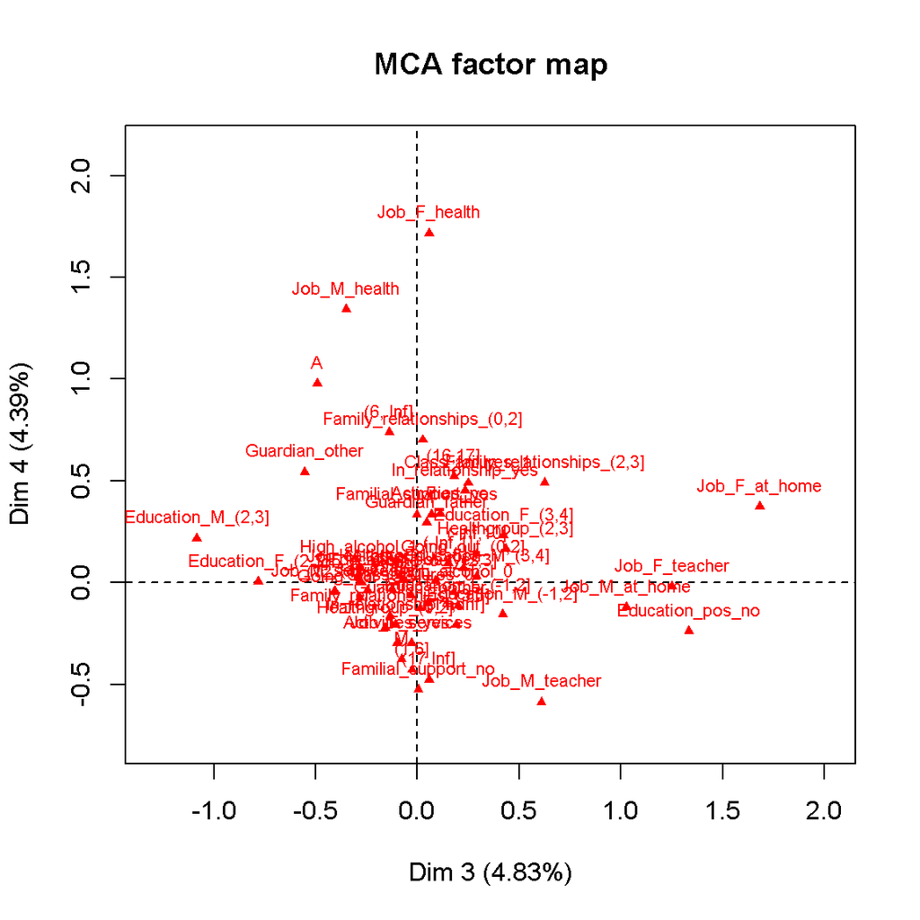

```r
plot(res_mca, invisible=c("ind"), select="contrib 20", axes=3:4,cex=0.7)
```

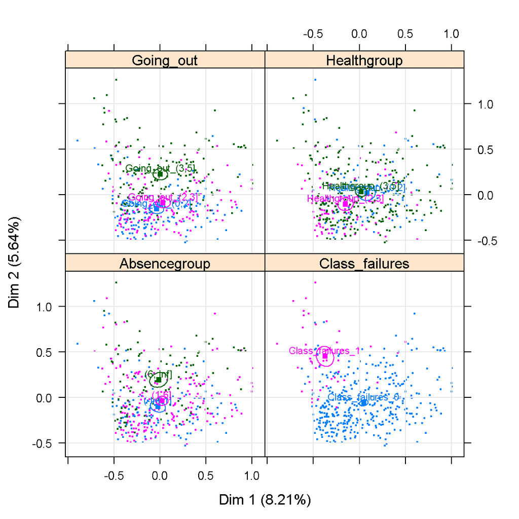

```r
plotellipses(res_mca, keepvar=c(14:17),cex=0.7)
```

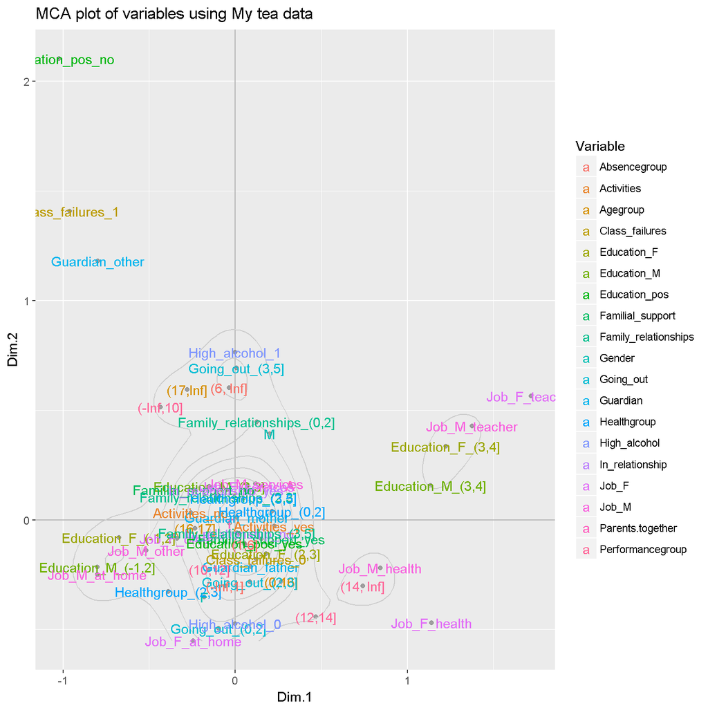

[figure not shown]

```r
 # MCA plot of observations and categories
dfalcqual<-dfalc[-19]
res.mca<-MCA(dfalcqual,graph=FALSE)
cats = apply(dfalcqual, 2, function(x) nlevels(as.factor(x)))

mca1_vars_df = data.frame(res.mca$var$coord, Variable = rep(names(cats), cats))

ggplot(data = mca1_vars_df, aes(x = Dim.1, y = Dim.2)) +
  geom_hline(yintercept = 0, colour = "gray70") +
  geom_vline(xintercept = 0, colour = "gray70") +
  geom_point(colour = "gray50", alpha = 0.7) +
  geom_density2d(colour = "gray80") +
  geom_text(data = mca1_vars_df,
            aes(x = Dim.1, y = Dim.2,
                label = rownames(mca1_vars_df), colour = Variable)) +
  ggtitle("MCA plot of variables using My tea data") +
  scale_colour_discrete(name = "Variable")
```

The **first cluster** has individuals with high frequencies for

- Class failures one or more
- Lowest performance group
- No willingness to higher education
- Oldest age group
- Guardian other than mother or father
- Going out frequently
- **High alcohol consumption**
- Mother’s and/or father’s low educational status
- Very good health status

and low frequencies for

- No class failures
- Mother’s high educational status
- Young age
- Father’s high educational status
- Low alcohol consumption
- Medium low performance

The **second cluster** has individuals with high frequencies for

- No class failures
- Mother’s or father’s low educational status
- Being a female
- Willingness to higher education
- Mother working as other
- Mother’s secondary education
- Average health
- Medium low performance
- Father’s job being other

and low frequencies for

- Mother´s and/or father’s education being higher
- Mother working as a teacher
- One or more failed classes
- Being a male
- Father working as a teacher
- Low performance
- No willingess to higher education
- Older age
- Going out with friends frequently

And, finally, the **third cluster** has individuals with high frequencies for

- Mother´s and/or father’s high educational status
- Mother and/or father working as a teacher
- No class failures
- Extra cullicular activities
- Mother working in the health care sector
- Being a male
- Father working in the health care sector
- Highest performance group

and low frequencies for

- Mother’s or father’s low educational status
- Mother working as other
- Mother’s education being secondary
- One or more class failures
- Mother being at home
- Father work as other
- No activities
- Being a female
- Lowest performance group

References:

- https://www.analyticsvidhya.com/blog/2016/03/practical-guide-principal-component-analysis-python/
- http://www.sthda.com/english/articles/31-principal-component-methods-in-r-practical-guide/114-mca-multiple-correspondence-analysis-in-r-essentials/#biplot
- https://georgemdallas.wordpress.com/2013/10/30/principal-component-analysis-4-dummies-eigenvectors-eigenvalues-and-dimension-reduction/
- http://factominer.free.fr/factomethods/categories-description.html http://factominer.free.fr/factomethods/dimensions-description.html
- http://factominer.free.fr/factomethods/multiple-correspondence-analysis.html
- http://www.gastonsanchez.com/visually-enforced/how-to/2012/10/13/MCA-in-R/